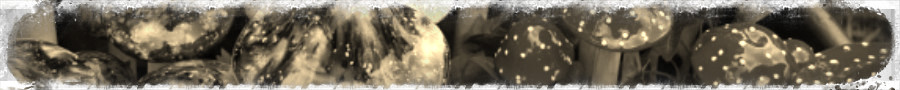

# Sample applications using data.tree

Christoph Glur

2015-11-06

# Introduction

This vignette gives you a quick introduction to data.tree applications. We took care to keep the examples simple enough so non-specialists can follow them. The price for this is, obviously, that the examples are often simple compared to real-life applications.

If you are using data.tree for things not listed here, and if you believe this is of general interest, then please do drop us a note, so we can include your application in a future version of this vignette.

# World PopulationTreeMap (visualisation)

This example is inspired by the examples of the treemap package.

You’ll learn how to

- convert a data.frame to a data.tree structure
- navigate a tree and locate specific nodes
- use `Aggregate` and `Cumulate`
- manipulate an existing tree, e.g. by using the `Prune` method

## Original Example, to be improved

The original example visualises the world population as a tree map.

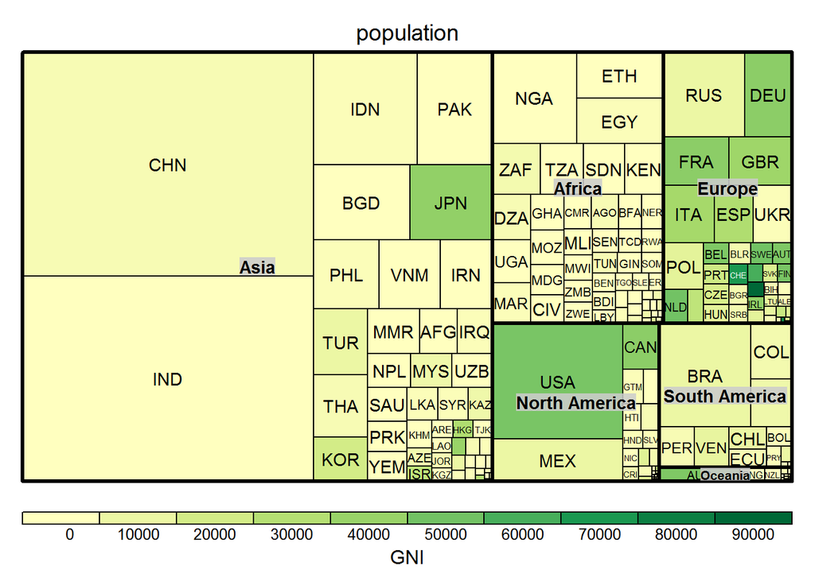

```r
library(treemap)
data(GNI2010)
treemap(GNI2010,
       index=c("continent", "iso3"),
       vSize="population",
       vColor="GNI",
       type="value")
```

As there are many countries, the chart gets clustered with many very small boxes. In this example, we will limit the number of countries and sum the remaining population in a catch-all country called “Other”.

We use data.tree to do this aggregation.

## Convert from data.frame

First, let’s convert the population data into a data.tree structure:

```r
library(data.tree)
GNI2010$pathString <- paste("world", GNI2010$continent, GNI2010$country, sep = "/")
n <- as.Node(GNI2010[,])
print(n, pruneMethod = "dist", limit = 20)
```

```
##                        levelName
## 1  world
## 2   ¦--North America
## 3   ¦   ¦--Aruba
## 4   ¦   ¦--Antigua and Barbuda
## 5   ¦   ¦--Bahamas
## 6   ¦   °--... 30 nodes w/ 0 sub
## 7   ¦--Asia
## 8   ¦   ¦--Afghanistan
## 9   ¦   ¦--United Arab Emirates
## 10  ¦   °--... 45 nodes w/ 0 sub
## 11  ¦--Africa
## 12  ¦   ¦--Angola
## 13  ¦   ¦--Burundi
## 14  ¦   °--... 52 nodes w/ 0 sub
## 15  ¦--Europe
## 16  ¦   ¦--Albania
## 17  ¦   ¦--Austria
## 18  ¦   °--... 41 nodes w/ 0 sub
## 19  ¦--South America
## 20  ¦   ¦--Argentina
## 21  ¦   ¦--Bolivia
## 22  ¦   °--... 10 nodes w/ 0 sub
## 23  °--Oceania
## 24      ¦--American Samoa
## 25      ¦--Australia
## 26      °--... 16 nodes w/ 0 sub
```

We can also navigate the tree to find the population of a specific country. Luckily, RStudio is quite helpful with its code completion (use `CTRL + SPACE`):

```r
n$Europe$Switzerland$population
```

```
## [1] 7826
```

Or, we can look at a sub-tree:

```r
northAm <- n$`North America`
northAm$Sort("GNI", decreasing = TRUE)
print(northAm, "iso3", "population", "GNI", limit = 12)
```

```
##                       levelName iso3 population   GNI
## 1  North America                             NA    NA
## 2   ¦--United States of America  USA     309349 47340
## 3   ¦--Canada                    CAN      34126 43250
## 4   ¦--Bahamas                   BHS        343 22240
## 5   ¦--Puerto Rico               PRI       3978 15500
## 6   ¦--Trinidad and Tobago       TTO       1341 15380
## 7   ¦--Antigua and Barbuda       ATG         88 13280
## 8   ¦--Saint Kitts and Nevis     KNA         52 11830
## 9   ¦--Mexico                    MEX     113423  8930
## 10  ¦--Panama                    PAN       3517  6970
## 11  ¦--Grenada                   GRD        104  6960
## 12  °--... 23 nodes w/ 0 sub                 NA    NA
```

Or, we can find out what is the country with the largest GNI:

```r
maxGNI <- Aggregate(n, "GNI", max)
#same thing, in a more traditional way:
maxGNI <- max(sapply(n$leaves, function(x) x$GNI))

n$Get("name", filterFun = function(x) x$isLeaf && x$GNI == maxGNI)
```

```
##   Norway
## "Norway"
```

## Aggregate and Cumulate

We aggregate the population. For non-leaves, this will recurse through children, and cache the result in the `population` field. The main reason why we do this is not to calculate the population of the world, but to store the result via the `cacheAttribute`.

```r
Aggregate(node = n,
          attribute = "population",
          aggFun = sum,
          cacheAttribute = "population")
```

```
## [1] 6727766
```

Next, we sort each node by population:

```r
n$Sort(attribute = "population", decreasing = TRUE, recursive = TRUE)
```

Finally, we cumulate among siblings, and store the running sum in an attribute called `cumPop`:

```r
n$Do(function(x) Cumulate(x, "population", sum, "cumPop"))
```

The tree now looks like this:

```r
print(n, "population", "cumPop", pruneMethod = "dist", limit = 20)
```

```
##                           levelName population  cumPop
## 1  world                               6727766 6727766
## 2   ¦--Asia                            4089247 4089247
## 3   ¦   ¦--China                       1338300 1338300
## 4   ¦   ¦--India                       1224615 2562915
## 5   ¦   ¦--Indonesia                    239870 2802785
## 6   ¦   °--... 44 nodes w/ 0 sub            NA      NA
## 7   ¦--Africa                           954502 5043749
## 8   ¦   ¦--Nigeria                      158423  158423
## 9   ¦   ¦--Ethiopia                      82950  241373
## 10  ¦   °--... 52 nodes w/ 0 sub            NA      NA
## 11  ¦--Europe                           714837 5758586
## 12  ¦   ¦--Russian Federation           141750  141750
## 13  ¦   ¦--Germany                       81777  223527
## 14  ¦   °--... 41 nodes w/ 0 sub            NA      NA
## 15  ¦--North America                    540446 6299032
## 16  ¦   ¦--United States of America     309349  309349
## 17  ¦   ¦--Mexico                       113423  422772
## 18  ¦   °--... 31 nodes w/ 0 sub            NA      NA
## 19  ¦--South America                    392162 6691194
## 20  ¦   ¦--Brazil                       194946  194946
## 21  ¦   ¦--Colombia                      46295  241241
## 22  ¦   °--... 10 nodes w/ 0 sub            NA      NA
## 23  °--Oceania                           36572 6727766
## 24      ¦--Australia                     22299   22299
## 25      ¦--Papua New Guinea               6858   29157
## 26      °--... 16 nodes w/ 0 sub            NA      NA
```

## Prune

The previous steps were done to define our threshold: big countries should be displayed, while small ones should be grouped together. This lets us define a pruning fuction that will allow a maximum of 7 countries per continent, and that will prune all countries making up less than 90% of a continent’s population:

```r
myPruneFun <- function(x, cutoff = 0.9, maxCountries = 7) {
  if (isNotLeaf(x)) return (TRUE)
  if (x$position > maxCountries) return (FALSE)
  return (x$cumPop < (x$parent$population * cutoff))
}
```

We clone the tree, because we might want to play around with different parameters:

```r
n2 <- Clone(n, pruneFun = myPruneFun)
print(n2$Oceania, "population", pruneMethod = "simple", limit = 20)
```

```
##              levelName population
## 1 Oceania                   36572
## 2  ¦--Australia             22299
## 3  °--Papua New Guinea       6858
```

Finally, we need to sum countries that we pruned away into a new “Other” node:

```r
n2$Do(function(x) {
  missing <- x$population - sum(sapply(x$children, function(x) x$population))
  other <- x$AddChild("Other")
  other$iso3 <- "OTH"
  other$country <- "Other"
  other$continent <- x$name
  other$GNI <- 0
  other$population <- missing
},
filterFun = function(x) x$level == 2
)
```

## Plot

### Plotting the treemap

In order to plot the treemap, we need to convert the data.tree structure back to a data.frame:

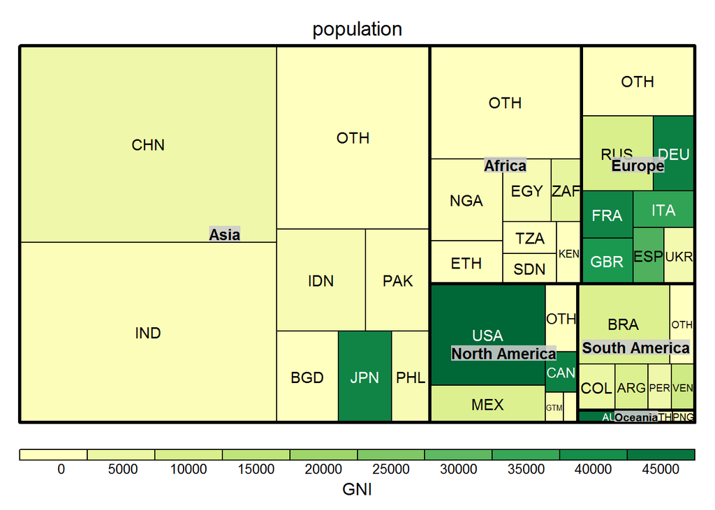

```r
df <- ToDataFrameTable(n2, "iso3", "country", "continent", "population", "GNI")

treemap(df,
        index=c("continent", "iso3"),
        vSize="population",
        vColor="GNI",
        type="value")
```

### Plot as dendrogram

Just for fun, and for no reason other than to demonstrate conversion to dendrogram, we can plot this in a very unusual way:

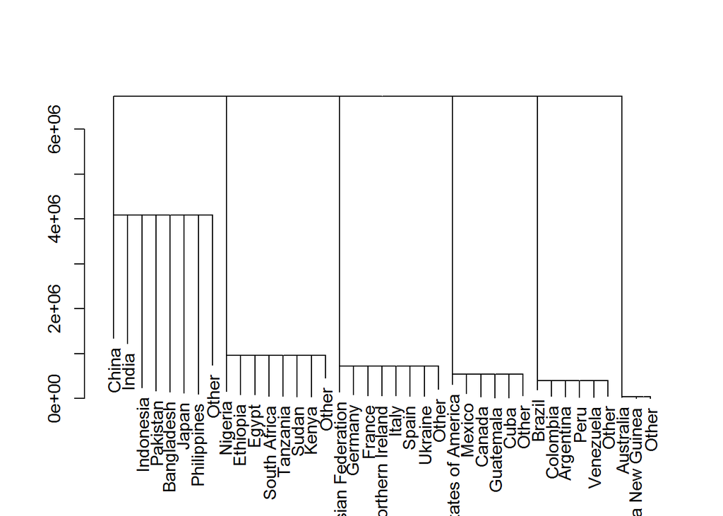

```r
plot(as.dendrogram(n2, heightAttribute = "population"))
```

## Further developments

Obviously, we should also aggregate the GNI as a weighted averag. Namely, we should do this for the *Other* catch-all country that we add to the tree.

# Portfolio Breakdown (finance)

In this example, we show how to display an investment portfolio as a hierarchic breakdown into asset classes. You’ll see:

- how you can re-use a traversal
- advanced use of `Aggregate`
- how to add default attribute formatters to your tree

## Convert from data.frame

```r
pfodf <- read.csv('../inst/extdata/portfolio.csv', stringsAsFactors = FALSE)
head(pfodf)
```

```
##           ISIN                                     Name Ccy Type Duration
## 1 LI0015327682          LGT Money Market Fund (CHF) - B CHF Fund       NA
## 2 LI0214880598        CS (Lie) Money Market Fund EUR EB EUR Fund       NA
## 3 LI0214880689        CS (Lie) Money Market Fund USD EB USD Fund       NA
## 4 LU0243957825    Invesco Euro Corporate Bond A EUR Acc EUR Fund     5.10
## 5 LU0408877412 JPM Euro Gov Sh. Duration Bd A (acc)-EUR EUR Fund     2.45
## 6 LU0376989207 Aberdeen Global Sel Emerg Mkt Bd A2 HEUR EUR Fund     6.80
##   Weight AssetCategory AssetClass        SubAssetClass
## 1  0.030          Cash        CHF
## 2  0.060          Cash        EUR
## 3  0.020          Cash        USD
## 4  0.120  Fixed Income        EUR Sov. and Corp. Bonds
## 5  0.065  Fixed Income        EUR Sov. and Corp. Bonds
## 6  0.030  Fixed Income        EUR       Em. Mkts Bonds
```

Let us convert the data.frame to a data.tree structure. Here, we use again the path string method. For other options, see `?as.Node.data.frame`

```r
pfodf$pathString <- paste("portfolio",
                          pfodf$AssetCategory,
                          pfodf$AssetClass,
                          pfodf$SubAssetClass,
                          pfodf$ISIN,
                          sep = "/")
pfo <- as.Node(pfodf)
```

## Aggregate

To calculate the weight per asset class, we use the `Aggregate` method:

```r
Aggregate(node = pfo, attribute = "Weight", aggFun = sum, cacheAttribute = "Weight")
```

```
## [1] 1
```

We now calculate the `WeightOfParent`,

```r
t <- Traverse(pfo, traversal = "post-order")
Do(t, function(x) x$WeightOfParent <- x$Weight / x$parent$Weight)
```

Duration is a bit more complicated, as this is a concept that applies only to the fixed income asset class. Note that, in the second statement, we are reusing the traversal from above.

```r
pfo$Do(function(x) x$Duration <- ifelse(is.null(x$Duration), 0, x$Duration), filterFun = isLeaf)
Do(t, function(x) x$Duration <- Aggregate(x, function(x) x$WeightOfParent * x$Duration, sum))
```

## Formatters

We can add default formatters to our data.tree structure. Here, we add them to the root, but we might as well add them to any Node in the tree.

```r
SetFormat(pfo, "WeightOfParent", function(x) FormatPercent(x, digits = 1))
SetFormat(pfo, "Weight", FormatPercent)

FormatDuration <- function(x) {
  if (x != 0) res <- FormatFixedDecimal(x, digits = 1)
  else res <- ""
  return (res)
}

SetFormat(pfo, "Duration", FormatDuration)
```

These formatter functions will be used when printing a data.tree structure.

## Print

```r
#Print
print(pfo,
      "Weight",
      "WeightOfParent",
      "Duration",
      filterFun = function(x) !x$isLeaf)
```

```
##                           levelName   Weight WeightOfParent Duration
## 1  portfolio                        100.00 %                     0.8
## 2   ¦--Cash                          11.00 %         11.0 %
## 3   ¦   ¦--CHF                        3.00 %         27.3 %
## 4   ¦   ¦--EUR                        6.00 %         54.5 %
## 5   ¦   °--USD                        2.00 %         18.2 %
## 6   ¦--Fixed Income                  28.50 %         28.5 %      3.0
## 7   ¦   ¦--EUR                       26.00 %         91.2 %      3.1
## 8   ¦   ¦   ¦--Sov. and Corp. Bonds  18.50 %         71.2 %      2.4
## 9   ¦   ¦   ¦--Em. Mkts Bonds         3.00 %         11.5 %      6.8
## 10  ¦   ¦   °--High Yield Bonds       4.50 %         17.3 %      3.4
## 11  ¦   °--USD                        2.50 %          8.8 %      1.6
## 12  ¦       °--High Yield Bonds       2.50 %        100.0 %      1.6
## 13  ¦--Equities                      40.00 %         40.0 %
## 14  ¦   ¦--Switzerland                6.00 %         15.0 %
## 15  ¦   ¦--Euroland                  14.50 %         36.2 %
## 16  ¦   ¦--US                         8.10 %         20.2 %
## 17  ¦   ¦--UK                         0.90 %          2.2 %
## 18  ¦   ¦--Japan                      3.00 %          7.5 %
## 19  ¦   ¦--Australia                  2.00 %          5.0 %
## 20  ¦   °--Emerging Markets           5.50 %         13.7 %
## 21  °--Alternative Investments       20.50 %         20.5 %
## 22      ¦--Real Estate                5.50 %         26.8 %
## 23      ¦   °--Eurozone               5.50 %        100.0 %
## 24      ¦--Hedge Funds               10.50 %         51.2 %
## 25      °--Commodities                4.50 %         22.0 %
```

# ID3 (machine learning)

This example shows you the following:

- How to build a data.tree structure in an algorithm
- How to prune a tree
- How to use data.tree to develop learning algorithms

Thanks a lot for all the helpful comments made by Holger von Jouanne-Diedrich.

Classification trees are very popular these days. If you have never come accross them, you might be interested in [classification trees](http://en.wikipedia.org/wiki/Decision_tree_learning). These models let you *classify* observations (e.g. things, outcomes) according to the observations’ qualities, called *features*. Essentially, all of these models consist of creating a *tree*, where each *node* acts as a *router*. You insert your mushroom *instance* at the *root* of the tree, and then, depending on the mushroom’s *features* (size, points, color, etc.), you follow along a different *path*, until a *leaf* node spits out your mushroom’s *class*, i.e. whether it’s edible or not.

There are two different steps involved in using such a model: *training* (i.e. constructing the tree), and *predicting* (i.e. using the tree to predict whether a given mushroom is poisonous). This example provides code to do both, using one of the very early algorithms to classify data according to discrete features: [ID3](http://en.wikipedia.org/wiki/ID3_algorithm). It lends itself well for this example, but of course today there are much more elaborate and refined algorithms available.

## ID3 Introduction

During the prediction step, each node routes our mushroom according to a feature. But how do we chose the feature? Should we first separate our set according to color or size? That is where classification models differ.

In ID3, we pick, at each node, the feature with the highest *Information Gain*. In a nutshell, this is the feature which splits the sample in the possibly *purest* subsets. For example, in the case of mushrooms, *dots* might be a more sensible feature than *organic*.

### Purity and Entropy

```r
IsPure <- function(data) {
  length(unique(data[,ncol(data)])) == 1
}
```

The *entropy* is a measure of the purity of a dataset.

```r
Entropy <- function( vls ) {
  res <- vls/sum(vls) * log2(vls/sum(vls))
  res[vls == 0] <- 0
  -sum(res)
}
```

### Information Gain

Mathematically, the information gain IG is defined as:

$$IG(T,a) = H(T)-\sum_{v\in vals(a)}\frac{|\{\textbf{x}\in T|x_a=v\}|}{|T|} \cdot H(\{\textbf{x}\in T|x_a=v\})$$

In words, the information gain measures the *difference* between the entropy *before the split*, and the weighted sum of the entropies *after the split*.

So, let’s rewrite that in R:

```r
InformationGain <- function( tble ) {
  entropyBefore <- Entropy(colSums(tble))
  s <- rowSums(tble)
  entropyAfter <- sum (s / sum(s) * apply(tble, MARGIN = 1, FUN = Entropy ))
  informationGain <- entropyBefore - entropyAfter
  return (informationGain)
}
```

## Training

We are all set for the ID3 training algorithm.

### Pseudo code

We start with the entire training data, and with a root. Then:

1. if the data-set is pure (e.g. all toxic), then
   1. construct a leaf having the name of the class (e.g. ‘toxic’)
2. else
   1. choose the feature with the highest information gain (e.g. ‘color’)
   2. for each value of that feature (e.g. ‘red’, ‘brown’, ‘green’)
      1. take the subset of the data-set having that feature value
      2. construct a child node having the name of that feature value (e.g. ‘red’)
      3. call the algorithm recursively on the child node and the subset

### Implementation in R with the data.tree package

For the following implementation, we assume that the classifying features are in columns 1 to n-1, whereas the class (the edibility) is in the last column.

```r
TrainID3 <- function(node, data) {

  node$obsCount <- nrow(data)

  #if the data-set is pure (e.g. all toxic), then
  if (IsPure(data)) {
    #construct a leaf having the name of the pure feature (e.g. 'toxic')
    child <- node$AddChild(unique(data[,ncol(data)]))
    node$feature <- tail(names(data), 1)
    child$obsCount <- nrow(data)
    child$feature <- ''
  } else {
    #calculate the information gain
    ig <- sapply(colnames(data)[-ncol(data)],
            function(x) InformationGain(
              table(data[,x], data[,ncol(data)])
              )
            )
    #chose the feature with the highest information gain (e.g. 'color')
    #if more than one feature have the same information gain, then take
    #the first one
    feature <- names(which.max(ig))
    node$feature <- feature

    #take the subset of the data-set having that feature value

    childObs <- split(data[ ,names(data) != feature, drop = FALSE],
                      data[ ,feature],
                      drop = TRUE)

    for(i in 1:length(childObs)) {
      #construct a child having the name of that feature value (e.g. 'red')
      child <- node$AddChild(names(childObs)[i])

      #call the algorithm recursively on the child and the subset
      TrainID3(child, childObs[[i]])
    }

  }



}
```

### Training with data

Our training data looks like this:

```r
library(data.tree)
data(mushroom)
mushroom
```

```
##   color  size points edibility
## 1   red small    yes     toxic
## 2 brown small     no    edible
## 3 brown large    yes    edible
## 4 green small     no    edible
## 5   red large     no    edible
```

Indeed, a bit small. But you get the idea.

We are ready to train our decision tree by running the function:

```r
tree <- Node$new("mushroom")
TrainID3(tree, mushroom)
print(tree, "feature", "obsCount")
```

```
##             levelName   feature obsCount
## 1  mushroom               color        5
## 2   ¦--brown          edibility        2
## 3   ¦   °--edible                      2
## 4   ¦--green          edibility        1
## 5   ¦   °--edible                      1
## 6   °--red                 size        2
## 7       ¦--large      edibility        1
## 8       ¦   °--edible                  1
## 9       °--small      edibility        1
## 10          °--toxic                   1
```

## Prediction

### The prediction method

We need a predict function, which will route data through our tree and make a prediction based on the leave where it ends up:

```r
Predict <- function(tree, features) {
  if (tree$children[[1]]$isLeaf) return (tree$children[[1]]$name)
  child <- tree$children[[features[[tree$feature]]]]
  return ( Predict(child, features))
}
```

### Using the prediction method

And now we use it to predict:

```r
Predict(tree, c(color = 'red',
                size = 'large',
                points = 'yes')
        )
```

```
## [1] "edible"
```

Oops, trusting classification blindly might be dangerous ;-)

# Jenny Lind (decision tree)

This demo calculates and plots a simple decision tree. It demonstrates the following:

- how to read a yaml file into a data.tree structure
- how to calculate a decision tree
- how to plot a data.tree with the ape package
- how to plot a data.tree with the DiagrammeR package

## Load YAML file

YAML is similar to JSON, but targeted towards humans (as opposed to computers). It’s consise and easy to read. YAML can be a neat format to store your data.tree structures, as you can use it across different software and systems, you can edit it with any text editor, and you can even send it as an email.

This is how our YAML file looks:

```r
fileName <- '../inst/extdata/jennylind.yaml'
cat(readChar(fileName, file.info(fileName)$size))
```

```
## name: Jenny Lind
## type: decision
## Sign with Movie Company:
##   type: chance
##   Small Box Office:
##     type: terminal
##     p: 0.3
##     payoff: 200000
##   Medium Box Office:
##     type: terminal
##     p: 0.6
##     payoff: 1000000
##   Large Box Office:
##     type: terminal
##     p: 0.1
##     payoff: 3000000
## Sign with TV Network:
##   type: chance
##   Small Box Office:
##     type: terminal
##     p: 0.3
##     payoff: 900000
##   Medium Box Office:
##     type: terminal
##     p: 0.6
##     payoff: 900000
##   Large Box Office:
##     type: terminal
##     p: 0.1
##     payoff: 900000
```

Let’s convert the YAML into a data.tree structure. First, we load it with the yaml package into a list of lists. Then we use `as.Node` to convert the list into a data.tree structure:

```r
#for debug
fileName <- './inst/extdata/jennylind.yaml'
```

```r
library(data.tree)
library(yaml)
l <- yaml.load_file(fileName)
jl <- as.Node(l)
print(jl, "type", "payoff", "p")
```

```
##                     levelName     type  payoff   p
## 1 Jenny Lind                  decision      NA  NA
## 2  ¦--Sign with Movie Company   chance      NA  NA
## 3  ¦   ¦--Small Box Office    terminal  200000 0.3
## 4  ¦   ¦--Medium Box Office   terminal 1000000 0.6
## 5  ¦   °--Large Box Office    terminal 3000000 0.1
## 6  °--Sign with TV Network      chance      NA  NA
## 7      ¦--Small Box Office    terminal  900000 0.3
## 8      ¦--Medium Box Office   terminal  900000 0.6
## 9      °--Large Box Office    terminal  900000 0.1
```

## Calculate

Next, we define our payoff function, and apply it to the tree. Note that we use post-order traversal, meaning that we calculate the tree from leaf to root:

```r
payoff <- function(node) {
  if (node$type == 'chance') node$payoff <- sum(sapply(node$children, function(child) child$payoff * child$p))
  else if (node$type == 'decision') node$payoff <- max(sapply(node$children, function(child) child$payoff))
}

jl$Do(payoff, traversal = "post-order", filterFun = isNotLeaf)
```

The decision function is the next step. Note that we filter on decision nodes:

```r
decision <- function(x) {
  po <- sapply(x$children, function(child) child$payoff)
  x$decision <- names(po[po == x$payoff])
}

jl$Do(decision, filterFun = function(x) x$type == 'decision')
```

## Plot

data.tree does not provide its own plotting facility, but there are plenty of options for plotting.

### Plot with the ape package

The ape package was built to manage and plot phylogenetic trees. However, its infrastructure can also be used to plot our decision tree.

First, we revert the order of the nodes in the tree (so it’s displayed from top to bottom, as ape does it the other way around). Then we convert the data.tree structure to a phylo object:

```r
library(ape)
jl$Revert()
jlp <- as.phylo(jl)
```

Now we are ready to plot.

First, we’ll define a function to format the node labels. We’ll use it later.

```r
Nodelabel <- function(node) {
  po <- paste0( '$ ', format(node$payoff, scientific = FALSE, big.mark = "'"))
  if (node$type == 'terminal') return (po)
  return ( paste0('ER\n', po) )
}
```

Here’s the plotting:

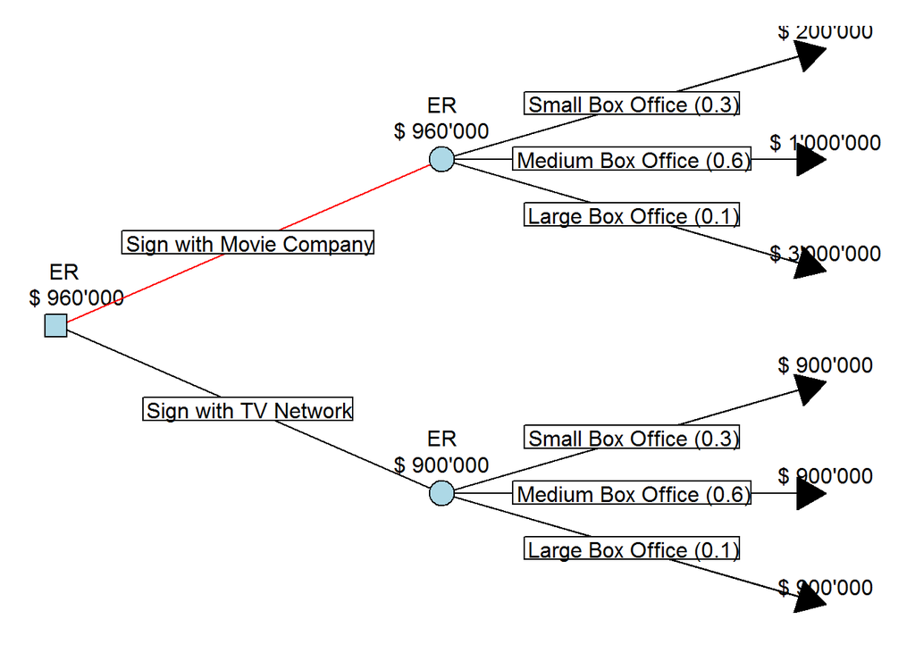

```r
par(mar=c(1,1,1,1))
plot(jlp, show.tip.label = FALSE, type = "cladogram")

#We set arrow heads to the leaf-edges:

for (node in jl$leaves) edges(GetPhyloNr(node$parent, "node"),
                              GetPhyloNr(node, "node"),
                              arrows = 2,
                              type = "triangle",
                              angle = 60)

#Finally, we iterate over all the nodes and print the labels. Note that the `GetPhyloNr`
#methods lets us map a `Node` in the data.tree to its counterpart in the phylo object.


for(node in Traverse(jl)) {
  if(node$type == 'decision') {
    nodelabels(Nodelabel(node), GetPhyloNr(node, "node"), frame = 'none', adj = c(0.3, -0.5))
  } else if(node$type == 'chance') {
    if (node$name == node$parent$decision) edges(GetPhyloNr(node$parent, "node"),
                                                 GetPhyloNr(node, "node"), col = "red")
    nodelabels(" ", GetPhyloNr(node, "node"), frame = "circle")
    nodelabels(Nodelabel(node), GetPhyloNr(node, "node"), frame = 'none', adj = c(0.5, -0.5))
    edgelabels(node$name, GetPhyloNr(node, "edge"), bg = "white")
  } else if(node$type == 'terminal') {
    tiplabels(Nodelabel(node), GetPhyloNr(node, "node"), frame = "none", adj = c(0.5, -0.6))
    edgelabels(paste0(node$name," (", node$p, ")"), GetPhyloNr(node, "edge"), bg = "white")
  }
}

nodelabels("   ", GetPhyloNr(jl, "node"), frame = "rect")
```

# Bubble Chart (visualisation)

In this example, we will replicate Mike Bostock’s bubble example. See here for details: http://bl.ocks.org/mbostock/4063269.  
We use Joe Cheng’s bubbles package. All of this is inspired by [Timelyportfolio](https://github.com/timelyportfolio), the king of [htmlwidgets](http://www.htmlwidgets.org).

You’ll learn how to convert a complex JSON into a data.frame, and how to use this to plot hierarchic visualisations.

## Load JSON file

The data represents the [Flare](http://flare.prefuse.org/) class hierarchy, which is a library for creating visualizations. The JSON is long, deeply nested, and complicated.

```r
flarePath <- '../inst/extdata/flare.json'
flareJSON <- readChar(flarePath, file.info(flarePath)$size)
cat(substr(flareJSON, 1, 300))
```

```
## {
##  "name": "flare",
##  "children": [
##   {
##    "name": "analytics",
##    "children": [
##     {
##      "name": "cluster",
##      "children": [
##       {"name": "AgglomerativeCluster", "size": 3938},
##       {"name": "CommunityStructure", "size": 3812},
##       {"name": "HierarchicalCluster", "size": 6714},
```

So, let’s convert it into a data.tree structure:

```r
library(jsonlite)
flareLoL <- fromJSON(file(flarePath),
                     simplifyDataFrame = FALSE
                     )

flareTree <- as.Node(flareLoL, mode = "explicit")
flareTree$fieldsAll
```

```
## [1] "size"
```

```r
print(flareTree, "size", limit = 30)
```

```
##                            levelName  size
## 1  flare                                NA
## 2   ¦--analytics                        NA
## 3   ¦   ¦--cluster                      NA
## 4   ¦   ¦   ¦--AgglomerativeCluster   3938
## 5   ¦   ¦   ¦--CommunityStructure     3812
## 6   ¦   ¦   ¦--HierarchicalCluster    6714
## 7   ¦   ¦   °--MergeEdge               743
## 8   ¦   ¦--graph                        NA
## 9   ¦   ¦   ¦--BetweennessCentrality  3534
## 10  ¦   ¦   ¦--LinkDistance           5731
## 11  ¦   ¦   ¦--MaxFlowMinCut          7840
## 12  ¦   ¦   ¦--ShortestPaths          5914
## 13  ¦   ¦   °--SpanningTree           3416
## 14  ¦   °--optimization                 NA
```

[output cut: 17 more lines]

Finally, we can convert it into a data.frame. The `ToDataFrameTable` only converts leafs, but inherits attributes from ancestors:

```r
flare_df <- ToDataFrameTable(flareTree,
                             className = function(x) x$parent$name,
                             packageName = "name",
                             "size")
head(flare_df)
```

```
##   className           packageName size
## 1   cluster  AgglomerativeCluster 3938
## 2   cluster    CommunityStructure 3812
## 3   cluster   HierarchicalCluster 6714
## 4   cluster             MergeEdge  743
## 5     graph BetweennessCentrality 3534
## 6     graph          LinkDistance 5731
```

This does not look spectacular. But take a look at this [stack overflow](http://stackoverflow.com/questions/31339805/converting-json-format-to-csv-to-upload-data-table-in-r-to-produce-d3-bubble-cha) question to see how people struggle to do this type of operation.

Here, it was particularly simple, because the underlying JSON structure is regular. If it were not (e.g. some nodes contain different attributes than others), the conversion from JSON to data.tree would still work. And then, as a second step, we could modify the data.tree structure before converting it into a data.frame. For example, we could use `Prune` and `Remove` to remove unwanted nodes, use `Set` to remove or add default values, etc.

## Plot

What follows has nothing to do with data.tree anymore. We simply provide the bubble chart printing for your enjoyment. In order to run it yourself, you need to install the bubbles package from github:

```r
devtools::install_github("jcheng5/bubbles@6724e43f5e")
library(scales)
library(bubbles)
library(RColorBrewer)
bubbles(
  flare_df$size,
  substr(flare_df$packageName, 1, 2),
  tooltip = flare_df$packageName,
  color = col_factor(
    brewer.pal(9,"Set1"),
    factor(flare_df$className)
  )(flare_df$className),
  height = 800,
  width = 800
)
```

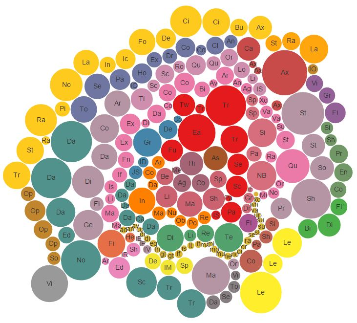

# File Explorer (system utilities)

In this example, we print the files that exist in the folder structure of the file system. As a special goodie, we’ll show code that lets you build your own *R File Explorer*, an interactive tree / list widget that lets you expand folders and browse through your file system.

## Print

First, let’s read the files in a directory tree into R. In this example, the root path “..” is the parent of the `vignettes` folder, i.e. the data.tree package folder itself:

```r
path <- ".."
files <- list.files(path = path,
                    recursive = TRUE,
                    include.dirs = FALSE)

df <- data.frame(
      filename = sapply(files,
                        function(fl) paste0("data.tree","/",fl)
      ),
      file.info(paste(path, files, sep = "/")),
      stringsAsFactors = FALSE
    )

print(head(df)[-c(3,5,6)], row.names = FALSE)
```

```
##                     filename  size mode               atime exe
##   data.tree/cran_comments.md   255  666 2015-09-07 12:32:56  no
##    data.tree/data.tree.Rproj   446  666 2015-09-08 22:39:47  no
##      data.tree/data/acme.rda 41275  666 2015-10-04 05:02:50  no
##  data.tree/data/mushroom.rda   263  666 2015-06-16 17:11:56  no
##    data.tree/data_gen/acme.R   892  666 2015-09-04 20:54:08  no
##  data.tree/data_gen/ball.csv   426  666 2015-06-16 17:11:56  no
```

We now convert this into a data.tree:

```r
fileStructure <- as.Node(df, pathName = "filename")
fileStructure$leafCount / (fileStructure$totalCount - fileStructure$leafCount)
```

```
## [1] 7.538462
```

```r
print(fileStructure, "mode", "size", limit = 25)
```

```
##                        levelName mode  size
## 1  data.tree                       NA    NA
## 2   ¦--cran_comments.md           438   255
## 3   ¦--data.tree.Rproj            438   446
## 4   ¦--data                        NA    NA
## 5   ¦   ¦--acme.rda               438 41275
## 6   ¦   °--mushroom.rda           438   263
## 7   ¦--data_gen                    NA    NA
## 8   ¦   ¦--acme.R                 438   892
## 9   ¦   ¦--ball.csv               438   426
## 10  ¦   ¦--ball.R                 438    99
## 11  ¦   °--mushroom.R             438   368
## 12  ¦--DESCRIPTION                438   970
## 13  ¦--inst                        NA    NA
## 14  ¦   °--extdata                 NA    NA
## 15  ¦       ¦--flare.json         438 11792
## 16  ¦       ¦--jennylind.yaml     438   557
## 17  ¦       ¦--portfolio.csv      438  2356
## 18  ¦       °--useR15.csv         438 19279
## 19  ¦--man                         NA    NA
## 20  ¦   ¦--acme.Rd                438   511
## 21  ¦   ¦--Aggregate.Rd           438  2401
## 22  ¦   ¦--AreNamesUnique.Rd      438   591
## 23  ¦   ¦--as.data.frame.Node.Rd  438  3831
## 24  ¦   ¦--as.dendrogram.Node.Rd  438  1216
## 25  ¦   °--... 38 nodes w/ 0 sub   NA    NA
## 26  °--... 6 nodes w/ 81 sub       NA    NA
```

## Listviewer html widget

Finally, we can display the files by timelyportfolio’s listviewer. As it’s not on CRAN, we only display a screenshot of the widget in in this vignette. This is not half as fun as the interactive widget, of course. So please try it out for yourself to see it in action.

```r
#This requires listviewer, which is available only on github
devtools::install_github("timelyportfolio/listviewer")

library(listviewer)

l <- ToListSimple(fileStructure)
jsonedit(l)
```

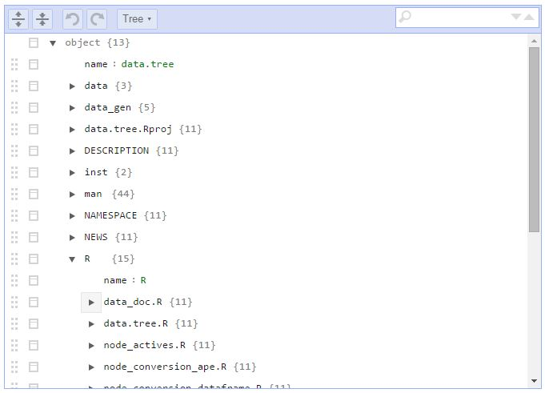

(Run the code yourself to see the widget in action)

# Gene Defect (genetics, probabilities, multi-generation models)

This is a simplistic example from the area of genetics. Similar models are found in many fields, namely wherever you have multi-generation models and probabilities.

The code generates 100 simulations of a 3 generation population. Individuals can inherit or develop a certain feature (e.g. colour blindness). The probability to develop the feature is based on sex. We then plot the probability distribution of the feature in the last generation.

You’ll learn how to build a data.tree structure according to probabilistic rules, and how to use the structure to infer a probability distribution.

## Algorithm

First, we generate a family tree of a population exhibiting a certain feature (e.g. colour blindness).

```r
#' @param children the number of children each population member has
#' @param probSex the probability of the sex of a descendant
#' @param probInherit the probability the feature is inherited, depending on the sex of the descendant
#' @param probDevelop the probability the feature is developed (e.g. a gene defect), depending on the sex
#' of the descendant
#' @param generations the number of generations our simulated population should have
#' @param parent for recursion
GenerateChildrenTree <- function(children = 2,
                                 probSex = c(male = 0.52, female = 0.48),
                                 probInherit = c(male = 0.8, female = 0.5),
                                 probDevelop = c(male = 0.05, female = 0.01),
                                 generations = 3,
                                 parent = NULL) {

  if (is.null(parent)) {
    parent <- Node$new("1")
    parent$sex <- 1
    parent$feature <- TRUE
    parent$develop <- FALSE
  }

  #sex of descendants
  #1 = male
  #2 = female
  sex <- sample.int(n = 2, size = children, replace = TRUE, prob = probSex)
  for (i in 1:children) child <- parent$AddChild(i)
  Set(parent$children, sex = sex)

  #inherit
  if (parent$feature == TRUE) {
    for (i in 1:2) {
      subPop <- Traverse(parent, filterFun = function(x) x$sex == i)
      inherit <- sample.int(n = 2,
                            size = length(subPop),
                            replace = TRUE,
                            prob = c(1 - probInherit[i], probInherit[i]))

      Set(subPop, feature = as.logical(inherit - 1))
    }
  } else {
    Set(parent$children, feature = FALSE)
  }

  #develop
  Set(parent$children, develop = FALSE)
  for (i in 1:2) {
    subPop <- Traverse(parent, filterFun = function(x) x$sex == i && !x$feature)
    develop <- sample.int(n = 2,
                          size = length(subPop),
                          replace = TRUE,
                          prob = c(1 - probDevelop[i], probDevelop[i]))
    Set(subPop, feature = as.logical((develop - 1)), develop = as.logical((develop - 1)))
  }

  #recursion to next generation
  if (generations > 0) for (i in 1:children) GenerateChildrenTree(children,
                                                                  probSex,
                                                                  probInherit,
                                                                  probDevelop,
                                                                  generations - 1,
                                                                  parent$children[[i]])

  return (parent)
}
```

## Analysis

Just for demonstration purpose, this is what a tree looks like:

```r
tree <- GenerateChildrenTree()
print(tree, "sex", "feature", "develop", limit = 20)
```

```
##                               levelName sex feature develop
## 1  1                                      1    TRUE   FALSE
## 2   ¦--1                                  2   FALSE   FALSE
## 3   ¦   ¦--1                              1   FALSE   FALSE
## 4   ¦   ¦   ¦--1                          1   FALSE   FALSE
## 5   ¦   ¦   ¦   ¦--1                      1    TRUE   FALSE
## 6   ¦   ¦   ¦   °--2                      1    TRUE   FALSE
## 7   ¦   ¦   °--2                          1    TRUE   FALSE
## 8   ¦   ¦       ¦--1                      2   FALSE   FALSE
## 9   ¦   ¦       °--2                      2    TRUE   FALSE
## 10  ¦   °--2                              1    TRUE   FALSE
## 11  ¦       ¦--1                          2   FALSE   FALSE
## 12  ¦       ¦   ¦--1                      1    TRUE   FALSE
## 13  ¦       ¦   °--2                      2    TRUE   FALSE
## 14  ¦       °--2                          1    TRUE   FALSE
## 15  ¦           ¦--1                      2    TRUE   FALSE
## 16  ¦           °--2                      1    TRUE   FALSE
## 17  °--2                                  1    TRUE    TRUE
## 18      ¦--1                              1   FALSE   FALSE
## 19      ¦   ¦--1                          1   FALSE   FALSE
## 20      ¦   ¦   °--... 2 nodes w/ 0 sub  NA      NA      NA
## 21      ¦   °--... 1 nodes w/ 4 sub      NA      NA      NA
## 22      °--... 1 nodes w/ 11 sub         NA      NA      NA
```

How big is our population after three generations?

```r
tree$totalCount
```

```
## [1] 31
```

For a given tree, how many have the feature?

```r
length(Traverse(tree, filterFun = function(x) x$feature))
```

```
## [1] 12
```

How many males have developed the feature without inheritance?

```r
length(Traverse(tree, filterFun = function(x) x$sex == 1 && x$develop))
```

```
## [1] 1
```

What is the occurrence of the feature in the last generation?

```r
FreqLastGen <- function(tree) {
  l <- tree$leaves
  sum(sapply(l, function(x) x$feature))/length(l)
}

FreqLastGen(tree)
```

```
## [1] 0.4375
```

## Simulation

Generate 100 sample trees and get the frequency of the feature in the last generation

```r
system.time(x <- sapply(1:100, function(x) FreqLastGen(GenerateChildrenTree())))
```

```
##    user  system elapsed
##    2.34    0.00    2.36
```

Plot a histogram of the frequency of the defect in the last generation:

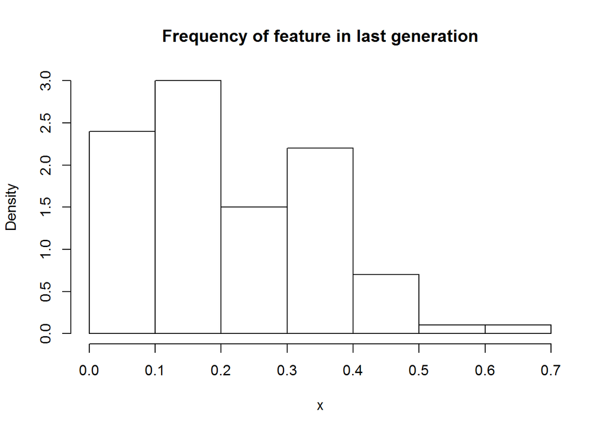

```r
hist(x, probability = TRUE, main = "Frequency of feature in last generation")
```

For larger populations, you might consider parallelisation, of course. See below for some hints.

## Parallelisation

It is straight forward to parallelise the simulation. If, as in this example, you do not need to pass around a data.tree structure from one process (fork) to another, it is also rather efficient.

```r
library(foreach)
library(doParallel)
registerDoParallel(makeCluster(3))
#On Linux, there are other alternatives, e.g.: library(doMC);  registerDoMC(3)

system.time(x <- foreach (i = 1:100, .packages = "data.tree") %dopar% FreqLastGen(GenerateChildrenTree()))
stopImplicitCluster()
```

```
##    user  system elapsed
##    0.07    0.02    1.40
```

For the more complicated case where you want to parallelise operations on a single tree, see below.

# Tic-Tac-Toe (game complexity)

In this example, we do a brute force solution of Tic-Tac-Toe, the well-known 3*3 game.

You’ll learn how data.tree can be used to build a tree of game history, and how the resulting data.tree structure can be used to analyse the game.

In addition, this example shows you how parallelisation can speed up data.tree.

We want to set up the problem in a way such that each `Node` is a move of a player, and each path describes the entire history of a game.

We number the fields from 1 to 9. Additionally, for easy readability, we label the Nodes in an Excel-like manner, such that field 9, say, is ‘c3’:

```r
fields <- expand.grid(letters[1:3], 1:3)
fields
```

```
##   Var1 Var2
## 1    a    1
## 2    b    1
## 3    c    1
## 4    a    2
## 5    b    2
## 6    c    2
## 7    a    3
## 8    b    3
## 9    c    3
```

To speed up things a bit, we consider rotation, so that, say, the first move in a3 and a1 are considered equal, because they could be achieved with a 90 degree rotation of the board. This leaves us with only a3, b3, and b2 for the first move of player 1:

```r
ttt <- Node$new("ttt")

#consider rotation, so first move is explicit
ttt$AddChild("a3")
ttt$a3$f <- 7
ttt$AddChild("b3")
ttt$b3$f <- 8
ttt$AddChild("b2")
ttt$b2$f <- 5


ttt$Set(player = 1, filterFun = isLeaf)
```

## Game play

Now we recurse through the tree, and add possible moves to the leaves, growing it eventally to hold all possible games. To do this, we define a method which, based on a `Node's` path, adds possible moves as children.

```r
AddPossibleMoves <- function(node) {
  t <- Traverse(node, traversal = "ancestor", filterFun = isNotRoot)

  available <- rownames(fields)[!rownames(fields) %in% Get(t, "f")]
  for (f in available) {
    child <- node$AddChild(paste0(fields[f, 1], fields[f, 2]))
    child$f <- as.numeric(f)
    child$player <- ifelse(node$player == 1, 2, 1)
    hasWon <- HasWon(child)
    if (!hasWon && child$level <= 10) AddPossibleMoves(child)
    if (hasWon) {
      child$result <- child$player
      print(paste("Player ", child$player, "wins!"))
    } else if(child$level == 10) {
      child$result <- 0
      print("Tie!")
    }

  }
  return (node)
}
```

Note that we store additional info along the way. For example, in the line `child$player <- ifelse(node$player == 1, 2, 1)`, the player is deferred from the parent `Node`, and set as an attribute in the `Node`.

## Exit Criteria

Our algorithm stops whenever either player has won, or when all 9 fields are taken. Whether a player has won is determined by this function:

```r
HasWon <- function(node) {
  t <- Traverse(node, traversal = "ancestor", filterFun = function(x) !x$isRoot && x$player == node$player)
  mine <- Get(t, "f")
  mineV <- rep(0, 9)
  mineV[mine] <- 1
  mineM <- matrix(mineV, 3, 3, byrow = TRUE)
  result <- any(rowSums(mineM) == 3) ||
    any(colSums(mineM) == 3) ||
    sum(diag(mineM)) == 3 ||
    sum(diag(t(mineM))) == 3
  return (result)
}
```

## Tree creation

The following code plays all possible games. Depending on your computer, this might take a few minutes:

```r
system.time(for (child in ttt$children) AddPossibleMoves(child))
```

```
##    user  system elapsed
## 345.645   3.245 346.445
```

## Analysis

What is the total number of games?

```r
ttt$leafCount
```

```
## [1] 89796
```

How many nodes (moves) does our tree have?

```r
ttt$totalCount
```

```
## [1] 203716
```

What is the average length of a game?

```r
mean(ttt$Get(function(x) x$level - 1, filterFun = isLeaf))
```

```
## [1] 8.400775
```

What is the average branching factor?

```r
ttt$averageBranchingFactor
```

```
## [1] 1.788229
```

How many games were won by each player?

```r
winnerOne <- Traverse(ttt, filterFun = function(x) x$isLeaf && x$result == 1)
winnerTwo <- Traverse(ttt, filterFun = function(x) x$isLeaf && x$result == 2)
ties <- Traverse(ttt, filterFun = function(x) x$isLeaf && x$result == 0)

c(winnerOne = length(winnerOne), winnerTwo = length(winnerTwo), ties = length(ties))
```

```
## winnerOne winnerTwo      ties
##     39588     21408     28800
```

We can, for example, look at any Node, using the `PrintBoard` function. This function prints the game history:

```r
PrintBoard <- function(node) {
  mineV <- rep(0, 9)


  t <- Traverse(node, traversal = "ancestor", filterFun = function(x) !x$isRoot && x$player == 1)
  field <- Get(t, "f")
  value <- Get(t, function(x) paste0("X", x$level - 1))
  mineV[field] <- value

  t <- Traverse(node, traversal = "ancestor", filterFun = function(x) !x$isRoot && x$player == 2)
  field <- Get(t, "f")
  value <- Get(t, function(x) paste0("O", x$level - 1))
  mineV[field] <- value

  mineM <- matrix(mineV, 3, 3, byrow = TRUE)
  rownames(mineM) <- letters[1:3]
  colnames(mineM) <- as.character(1:3)
  mineM
}
```

```r
PrintBoard(ties[[1]])
```

```
##   1    2    3
## a "O2" "X3" "O4"
## b "X5" "O6" "X7"
## c "X1" "O8" "X9"
```

Exercise: Do the same for Chess!

## Parallelisation

Here, the parallelisation is more challenging as with the Gene Defect example above. The reason is that we have only one tree, albeit a big one. So we need a strategy to do what we call intra-tree parallelisation.

In a perfect world, data.tree and intra-tree parallelisation would tell a love story: Many operations are recursive, and can be called equally well on a subtree or on an entire tree. Therefore, it is very natural to delegate the calculation of multiple sub-trees to different processes.

For example, tic-tac-toe seems almost trivial to parallelise: Remember that, on level 2, we created manually 3 `Nodes`. The creation of the sub-trees on these `Nodes` will be completely independent on the other sub-trees. Then, each sub-tree can be created in its own process.

So, in theory, we could use any parallelisation mechanism available in R. Unfortunately, you need to take into account a few things. As a matter of fact, to pass the sub-trees from a fork process back to the main process, R needs to serialize the `Nodes` of the sub-tree, and this results in huge objects. As a result, collecting the sub-trees would take ages.

So, instead, we can

1. create the sub-trees, each in its own process
2. run the analysis in the child process
3. return the result of the analysis to the main process
4. aggregate the results

```r
AnalyseTicTacToe <- function(subtree) {
  # 1. create sub-tree
  AddPossibleMoves(subtree)
  # 2. run the analysis
  winnerOne <- Traverse(subtree, filterFun = function(x) x$isLeaf && x$result == 1)
  winnerTwo <- Traverse(subtree, filterFun = function(x) x$isLeaf && x$result == 2)
  ties <- Traverse(subtree, filterFun = function(x) x$isLeaf && x$result == 0)

  res <- c(winnerOne = length(winnerOne),
           winnerTwo = length(winnerTwo),
           ties = length(ties))
  # 3. return the result
  return(res)
}


library(foreach)
library(doParallel)
registerDoParallel(makeCluster(3))
#On Linux, there are other alternatives, e.g.: library(doMC);  registerDoMC(3)
system.time(
  x <- foreach (child = ttt$children,
                .packages = "data.tree") %dopar% AnalyseTicTacToe(child)
)
```

```
##    user  system elapsed
##    0.05    0.04  116.86
```

```r
stopImplicitCluster()
# 4. aggregate results
rowSums(sapply(x, c))
```

```
## winnerOne winnerTwo      ties
##     39588     21408     28800
```